# Properties of matrices 行列の特徴

ryamada

2016年12月22日

# 1 似ている行列 (相似) Matrix similarity

When we use matrices for statistical analyses, we change bases so that “better” axes should grab data sets in simpler or better ways.

The change of bases are achieved with linear transformation. Therefore matrices that are transformed each other by linear transformation should be considered “similar”.

Among the similar matrices, the simplest one tends to represent data structure the “best” way from data interpretation standpoint.

The simplest one among the similar matrices is Jordan normal.

Or the simplest one is diagonal, if diagonalizable, and, in many cases the matrices in statistical analyses are diagonizable.

統計解析に行列を使うとき、データセットが単純に理解できるような基底の取り直しをすることがよくある。

基底の取り直しは線形変換で行うので、線形変換で互いに行きあえる行列同市は「相似(似ている)」関係にあると言う。

相互に相似な関係にある行列の中で、最も単純な行列を代表とすることがあり、それを使うことでデータ解釈が最もわかりやすくなる。

相似な行列の中で最も単純なのは、ジョルダン標準形のそれである。

対角化可能な行列なら、ジョルダン標準形は対角化行列である。実際、統計解析で現れる行列の多くは、対角化可能である。

任意の正方行列$M$はジョルダン標準形$J$と逆行列を持つ行列$R$とを用いて、次のように表せる。

$$M = R J R^{-1}$$

$M' = R'JR'^{-1}$となるとき、$M$と$M'$は相似であると言う。

以下では、ジョルダン標準形が対角行列であるようなもの(対角化可能行列)に絞って話を進めるが、特に断らなければ、提示している性質等は対角化可能行列に限るものではない。

# 2 相似行列に共通する特徴量

相互に相似な行列は見かけは違うが、「本質的に同じ」なので、その「本質」に関する性質は共通である。

- 階数(Rank)
- 行列式(Determinant)
- トレース(跡) (Trace)
- 固有値(Eigen values)

## 2.1 Rでの計算

Rank, Determinant, Trace, Eigen valuesは次のように計算できる

```r
library(Matrix)
d <- 4
M <- matrix(rnorm(d^2),d,d)
eigen(M)[[1]]
```

```
## [1] -1.1741118+0.9913840i -1.1741118-0.9913840i  0.5786552+0.7952877i
## [4]  0.5786552-0.7952877i
```

```r
rankMatrix(M)[[1]]
```

```
## [1] 4
```

```r
det(M)
```

```
## [1] 2.284221
```

```r
sum(diag(M)) # Trace
```

```
## [1] -1.190913
```

# 3 Exercise 1

## 3.1 Exercise 1-1

逆行列を持つ行列Rを使って、対角行列Jを変換した行列M($M=RJR^{-1}$)がJと相似であることを、固有値が一致していることを確認して確かめよ。

そして、ランク、行列式、トレースが同一であることを確かめよ。

```r
d <- 4
J <- diag(rnorm(d))
R <- matrix(rnorm(d^2),d,d)
M <- R %*% J %*% solve(R)
eigen(J)[[1]]
```

```
## [1]  0.4955596  0.4456923 -0.1680365 -0.9141442
```

```r
eigen(M)[[1]]
```

```
## [1] -0.9141442  0.4955596  0.4456923 -0.1680365
```

```r
rankMatrix(J)[[1]]
```

```
## [1] 4
```

```r
rankMatrix(M)[[1]]
```

```
## [1] 4
```

```r
det(J)
```

```
## [1] 0.03392731
```

```r
det(M)
```

```
## [1] 0.03392731
```

```r
sum(diag(J)) # Trace
```

```
## [1] -0.1409288
```

```r
sum(diag(M)) # Trace
```

```
## [1] -0.1409288
```

## 3.2 Exercise 1-2

行列が相互に相似かどうかは、(すべての固有値が異なるならば)固有値のセットが等しいことで確認できる。

したがって相似な行列に共通する特徴は、固有値と紐づけて算出できるはずである。

以下を確かめよ。

$d$個の異なる固有値を持つ行列を作り、それと相似な行列を複数作れ。

それらの固有値のセットが一致すること、トレース・行列式が一致することを確かめよ。

また、トレースの計算は、対角成分の和を取る方法と、固有値の和を取る方法の両方を実施せよ。 行列式の計算もdet()関数を使用する方法と固有値の積を取る方法の両方を実施せよ。

```
## [[1]]
## [1] -0.0004091244
##
## [[2]]
## [1] -0.0004091244
##
## [[3]]
## [1] -0.0004091244
##
## [[4]]
## [1] -0.0004091244
##
## [[5]]
## [1] -0.0004091244
##
## [[6]]
## [1] -0.0004091244
##
## [[7]]
## [1] -0.0004091244
##
## [[8]]
## [1] -0.0004091244
##
## [[9]]
## [1] -0.0004091244
##
## [[10]]
## [1] -0.0004091244
```

```
## [[1]]
## [1] -11.612590   8.736930   3.415908  -1.971686
##
## [[2]]
## [1] -2.47443331  1.55825946 -0.43920254 -0.07606178
##
## [[3]]
## [1] -0.6768818 -0.1819945 -0.8542280  0.2816662
##
## [[4]]
## [1]  1.5433476  0.1180999 -2.4963997 -0.5964859
##
## [[5]]
## [1]  0.6039185 -1.4078521 -0.4202507 -0.2072539
##
## [[6]]
## [1]  1.2912410 -5.6506502  2.5405990  0.3873721
##
## [[7]]
## [1]  0.6876451  1.0517309  0.5574392 -3.7282534
##
## [[8]]
## [1] -1.49928360 -0.43924960  0.58623485 -0.07913983
##
## [[9]]
## [1] -2.08933580 -0.07569291  0.66716061  0.06642992
##
## [[10]]
## [1]  12.6960258 -11.8824854  -0.5644387  -1.6805399
```

```
## [[1]]
## [1] -1.46323305  0.12643222 -0.05256953 -0.04206782
##
## [[2]]
## [1] -1.46323305  0.12643222 -0.05256953 -0.04206782
##
## [[3]]
## [1] -1.46323305  0.12643222 -0.05256953 -0.04206782
##
## [[4]]
## [1] -1.46323305  0.12643222 -0.05256953 -0.04206782
##
## [[5]]
## [1] -1.46323305  0.12643222 -0.05256953 -0.04206782
##
## [[6]]
## [1] -1.46323305  0.12643222 -0.05256953 -0.04206782
##
## [[7]]
## [1] -1.46323305  0.12643222 -0.05256953 -0.04206782
##
## [[8]]
## [1] -1.46323305  0.12643222 -0.05256953 -0.04206782
##
## [[9]]
## [1] -1.46323305  0.12643222 -0.05256953 -0.04206782
##
## [[10]]
## [1] -1.46323305  0.12643222 -0.05256953 -0.04206782
```

# 4 対称行列

$M=M^T$である正方行列を対称行列と言う。

対称行列は
$$M = R J R^{-1} = R J R^T\\
R^T=R^{-1}\\
R R^T = R^T R = I$$
と対角化で現れる行列$R$が特別な性質(直交行列)を持つ。

確かめてみる。

```r
d <- 5
n.iter <- 10
for(i in 1:n.iter){
  M <- matrix(rnorm(d^2),d,d)
  M <- M + t(M) # 対称行列化
  eigen.out <- eigen(M)
  print(round(eigen.out[[2]] %*% t(eigen.out[[2]]),8))
}
```

```
##      [,1] [,2] [,3] [,4] [,5]
## [1,]    1    0    0    0    0
## [2,]    0    1    0    0    0
## [3,]    0    0    1    0    0
## [4,]    0    0    0    1    0
## [5,]    0    0    0    0    1
##      [,1] [,2] [,3] [,4] [,5]
## [1,]    1    0    0    0    0
## [2,]    0    1    0    0    0
## [3,]    0    0    1    0    0
## [4,]    0    0    0    1    0
## [5,]    0    0    0    0    1
##      [,1] [,2] [,3] [,4] [,5]
## [1,]    1    0    0    0    0
## [2,]    0    1    0    0    0
```

[output cut: 45 more lines]

# 5 Exercise 2

## 5.1 Exercise 2-1

対角行列と直交行列によって相似な関係にある行列を複数作り、それらが対称行列であることを確かめよ。

なお、直交行列をランダムに発生するには、GPRrotation::Rnadom.Start()関数を用いるとよい。

```
## [1] "unit?"
##      [,1] [,2] [,3] [,4] [,5]
## [1,]    1    0    0    0    0
## [2,]    0    1    0    0    0
## [3,]    0    0    1    0    0
## [4,]    0    0    0    1    0
## [5,]    0    0    0    0    1
## [1] "zero?"
##      [,1] [,2] [,3] [,4] [,5]
## [1,]    0    0    0    0    0
## [2,]    0    0    0    0    0
## [3,]    0    0    0    0    0
## [4,]    0    0    0    0    0
## [5,]    0    0    0    0    0
## [1] "unit?"
```

[output cut: 125 more lines]

# 6 距離行列 分散共分散行列 対称行列 固有値が正 正定値行列

行列には相似という間柄があり、それは固有値で決まることが分かった。

また、相似な行列の間で保存される性質があることもわかった。

また、$R M R^{-1}$という変換が相似な行列を作ることもわかった。

また対象行列の場合 $R M R^{-1} = R M R^T$と書け、Rが直交行列であることもわかった。

これらは、一般的な行列の話であったが、この節では、統計解析でよく登場する特別な行列を取り上げ、その場合に固有値・相似行列の特徴がどのような性質を持つかを確認する。

## 6.1 距離行列

$n$個の要素があって、それらの要素ペアの距離を行列とすることがある。

要素間の関連を調べるときの基本的なデータ構造であり

距離の場合、自身から自身への距離は0である。 自身以外への距離は正である。

AからBへの距離とBからAへの距離は同じなので、距離行列は、次の性質を持つ。

- 対角成分が0
- 対称
- 非対角成分は正

このような行列では、以下のような特徴がある。

```r
d <- 5
M <- matrix(abs(rnorm(d^2)),d,d)
diag(M) <- 0
M <- M+t(M) # 対称にする

eigen.out <- eigen(M)
trace <- sum(diag(M)) # zero
trace2 <- sum(eigen.out[[1]])
determinant <- det(M)
determinant2 <- prod(eigen.out[[1]])

eigen.out[[1]] # Negative and positive eigen values
```

```
## [1]  5.5789604  0.1556252 -0.7320391 -1.2424011 -3.7601454
```

```r
round(eigen.out[[2]] %*% t(eigen.out[[2]]),6) # 固有値ベクトルが作る行列は直交
```

```
##      [,1] [,2] [,3] [,4] [,5]
## [1,]    1    0    0    0    0
## [2,]    0    1    0    0    0
## [3,]    0    0    1    0    0
## [4,]    0    0    0    1    0
## [5,]    0    0    0    0    1
```

## 6.2 分散共分散行列

$k$個の変数、$n$個のサンプルがあるとき、$k\times k$の分散共分散行列が算出できる。

対角成分は$k$個の変数の分散である。 トレースは$k$個の変数の分散の和である。

$k$個の変数の分散の和が固有値の和である。

対称行列である。これは距離行列の場合と同じ。

```r
k <- 5
n <- 100
X <- matrix(0,n,k)
X[,1] <- rnorm(n)
for(i in 2:k){
X[,i] <- rnorm(n) + X[,i-1]
}
M <- cov(X)
M
```

```
##           [,1]      [,2]      [,3]      [,4]      [,5]
## [1,] 0.9237420 0.8361656 0.8443777 0.8773991 0.7178514
## [2,] 0.8361656 1.7435079 1.9513828 1.8298230 1.6240981
## [3,] 0.8443777 1.9513828 3.0667371 2.9675999 2.6337225
## [4,] 0.8773991 1.8298230 2.9675999 3.8318982 3.4805980
## [5,] 0.7178514 1.6240981 2.6337225 3.4805980 4.1203933
```

```r
round(M-t(M),8) # 対称行列
```

```
##      [,1] [,2] [,3] [,4] [,5]
## [1,]    0    0    0    0    0
## [2,]    0    0    0    0    0
## [3,]    0    0    0    0    0
## [4,]    0    0    0    0    0
## [5,]    0    0    0    0    0
```

```r
det(M)
```

```
## [1] 0.698088
```

```r
sum(diag(M))
```

```
## [1] 13.68628
```

```r
eigen.out <- eigen(M)
round(eigen.out[[2]] %*% t(eigen.out[[2]]),8)
```

```
##      [,1] [,2] [,3] [,4] [,5]
## [1,]    1    0    0    0    0
## [2,]    0    1    0    0    0
## [3,]    0    0    1    0    0
## [4,]    0    0    0    1    0
## [5,]    0    0    0    0    1
```

```r
eigen.out[[1]]
```

```
## [1] 11.0961899  1.4065392  0.6052861  0.3876234  0.1906399
```

分散共分散行列は、対象行列であって、対角成分はすべて正。

また、以下に示すように、固有値もすべて正。

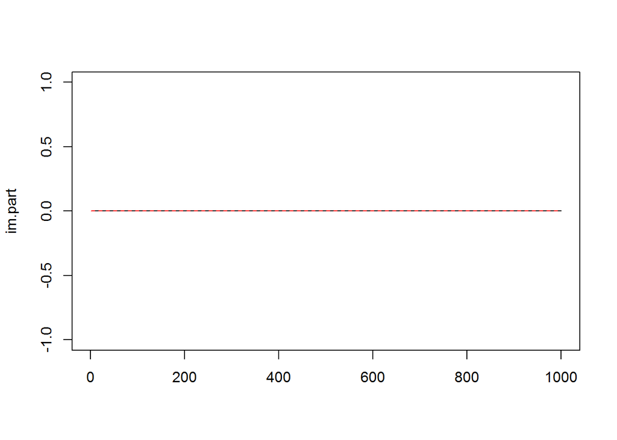

```r
n.iter <- 1000
im.part <- matrix(0,n.iter,2)
re.part <- matrix(0,n.iter,2)
for(i in 1:n.iter){
  d <- sample(2:50,1)
  X <- matrix(0,n,k)
  X[,1] <- rnorm(n)
  for(j in 2:k){
    X[,j] <- rnorm(n) + X[,j-1]
  }
  M <- cov(X)
  M
  eigen.out <- eigen(M)
  im.part[i,] <- range(Im(eigen.out[[1]]))
  re.part[i,] <- range(Re(eigen.out[[1]]))
}

matplot(im.part,type="l")
```

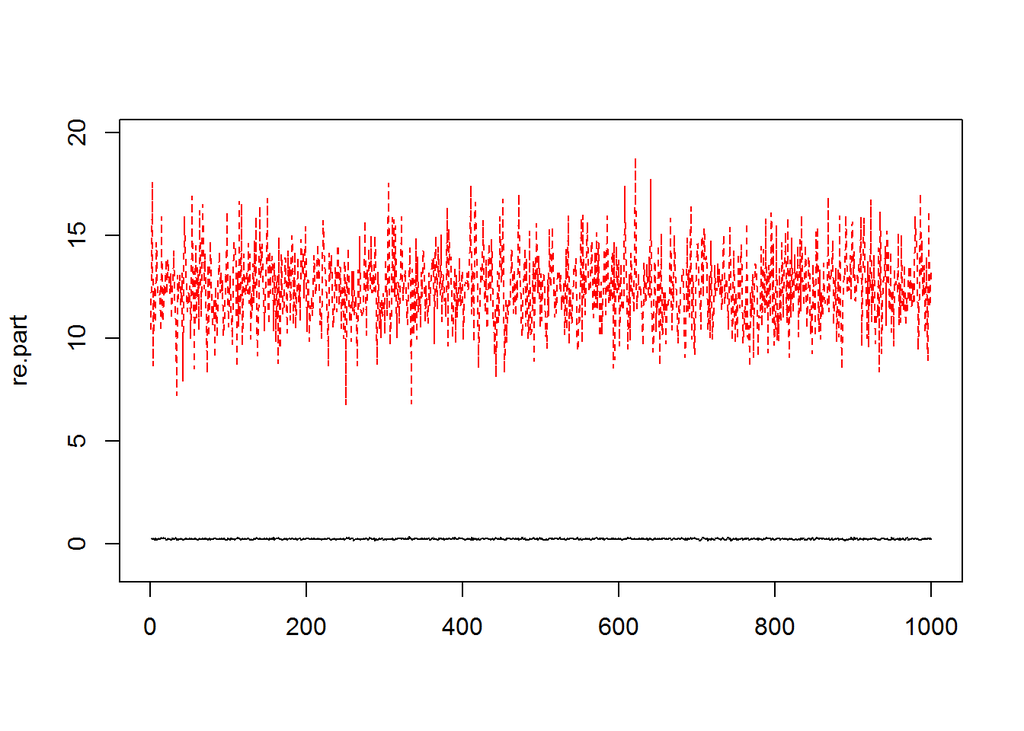

```r
matplot(re.part,type="l",ylim=c(-1,max(re.part)+1))
```

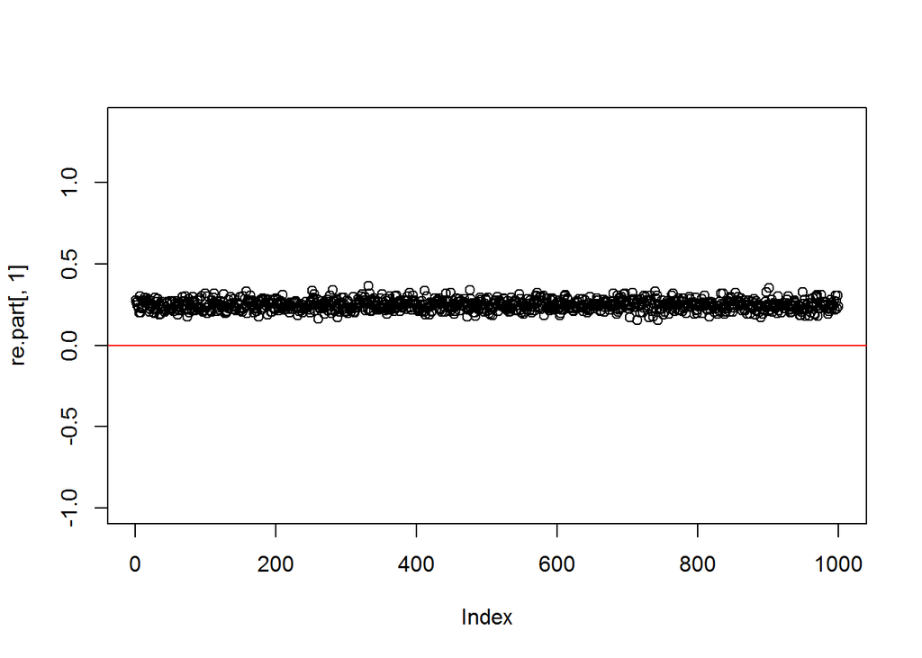

```r
plot(re.part[,1],ylim=c(-1,max(re.part[,1]+1)))
abline(h=0,col=2)
```

```r
min(re.part[,1])
```

```
## [1] 0.1546466
```